# Grasses from the NVD plot data

A quick overview of the data. There are 2 files, a spp by site/plot matrix “grassmatrix_PA.csv” (object *gdat* below) and ancillary data for each plot “grass_PA_plotdat.csv” (object *d*), which includes plot spatial location, species richness etc. Note that the column “RELEVE_NR” in *d* matches the rownames of *gdat*.

Data cleaning steps implemented so far:

1. Data that had no location confidence information (column Loc_Conf) were excluded (~150 plots).
2. Plots >1km from the coast or borders of SA were excluded (i.e. they won’t fall within any 30s grid environmental data so why bother keeping them…).
3. Plots with no surface area information were excluded.
4. Plots where grass species weren’t sampled were excluded (e.g. “Woody only”, etc). There are some subtle differences between the survey protocols used for the plots that remain (“All species present”, “Full floristics”, “Permanently recognisable species”, “Grasses, extremely few other”) in that we don’t know if “All species present” and “Full floristics” include or exclude “Seasonally recognizable species” or if the author of the original study gave any thought to the difference… We may need to think about which grasses are perennially vs seasonally recognizable?
5. Note that I HAVE NOT excluded any alien species. I figured you’d want them :)

Please let me know if you spot any errors or would like me to change any of the above.

Ok, let’s look at the data

```r
library(ggplot2)
library(maps)
library(maptools)
library(raster)
library(sp)
gdat <- read.csv("/Users/jasper/GIT/VegMapTools/Data/grassmatrix_PA.csv", stringsAsFactors = F, row.names = 1)
d <- read.csv("/Users/jasper/GIT/VegMapTools/Data/grass_PA_plotdat.csv", stringsAsFactors = F, row.names = 1)
```

so there are 13294 plots and 504 genera.

First off, there is an issue of varying plot size. The number of plots in each size class are indicated below:

```r
summary(as.factor(d$SURF_AREA)) #100m2 looks best...
```

```
0.319999993           3           4           5           7           8
          1           1          43           3           2           5
9.199999809          10          11          12          13          15
          1           6           2           3           6          19
         16        16.5          17          18          19          20
       2281           1           2           8           2          21
         21          22          24          25          26 26.10000038
          2           5           5        1423           4           1
         27          28          30          31          32          34
          4           6          20           1           4           2
         35          36          39          40          42          44
         10           3           2          13           1           3
         45          46          47          49          50          53
          9           1           1           3         867           2
         55          60          64          67          68          70
          2           4          11           2          19           6
         80          90         100         108         110         120
          4           1        5237           2           1           1
        140         200         225         256         400         900
          2        2455           1           5         518         224
```

How is that split up by biome?

```r
table(d$Biome, d$SURF_AREA)
```

```
                            0.319999993    3    4    5    7    8 9.199999809
  Albany Thicket Biome                0    0    0    0    0    0           0
  Azonal Vegetation                   0    0    0    0    0    0           0
  Forests                             0    0    0    0    0    0           0
  Fynbos Biome                        1    1   42    3    2    5           1
  Grassland Biome                     0    0    1    0    0    0           0
  Indian Ocean Coastal Belt           0    0    0    0    0    0           0
  Nama-Karoo Biome                    0    0    0    0    0    0           0
  Savanna Biome                       0    0    0    0    0    0           0
  Succulent Karoo Biome               0    0    0    0    0    0           0
  Waterbodies                         0    0    0    0    0    0           0

                              10   11   12   13   15   16 16.5   17   18   19
  Albany Thicket Biome         0    0    0    0    0    0    0    0    0    0
  Azonal Vegetation            0    0    0    0    0  152    0    0    0    0
  Forests                      0    0    0    0    0    0    0    0    0    0
  Fynbos Biome                 6    2    3    5   17    4    1    2    8    2
  Grassland Biome              0    0    0    1    2 2112    0    0    0    0
  Indian Ocean Coastal Belt    0    0    0    0    0    1    0    0    0    0
  Nama-Karoo Biome             0    0    0    0    0    0    0    0    0    0
  Savanna Biome                0    0    0    0    0   12    0    0    0    0
  Succulent Karoo Biome        0    0    0    0    0    0    0    0    0    0
  Waterbodies                  0    0    0    0    0    0    0    0    0    0

                              20   21   22   24   25   26 26.10000038   27   28
  Albany Thicket Biome         0    0    0    0    0    0           0    0    0
  Azonal Vegetation            0    0    0    0   18    0           0    0    0
  Forests                      0    0    0    0  119    0           0    0    0
  Fynbos Biome                20    1    5    0   18    4           1    4    3
  Grassland Biome              1    1    0    5 1101    0           0    0    3
  Indian Ocean Coastal Belt    0    0    0    0   26    0           0    0    0
  Nama-Karoo Biome             0    0    0    0   93    0           0    0    0
  Savanna Biome                0    0    0    0   39    0           0    0    0
  Succulent Karoo Biome        0    0    0    0    5    0           0    0    0
  Waterbodies                  0    0    0    0    0    0           0    0    0

                              30   31   32   34   35   36   39   40   42   44
  Albany Thicket Biome         0    0    0    0    0    0    0    0    0    0
  Azonal Vegetation            0    0    0    0    0    0    0    0    0    0
  Forests                      0    0    0    0    0    0    2    0    0    0
```

[output cut: 28 more lines]

```
  Savanna Biome               12    0    0    0  526    0    0    0    0 2078
  Succulent Karoo Biome        0    0    0    0    0    0    0    0    0    0
  Waterbodies                  0    0    0    0    3    0    0    0    0    0

                             225  256  400  900
  Albany Thicket Biome         0    0    0    0
  Azonal Vegetation            0    0   13   18
  Forests                      0    0   21    0
  Fynbos Biome                 0    5   42    0
  Grassland Biome              1    0   97    0
  Indian Ocean Coastal Belt    0    0    0    0
  Nama-Karoo Biome             0    0   92   98
  Savanna Biome                0    0  127  108
  Succulent Karoo Biome        0    0  126    0
  Waterbodies                  0    0    0    0
```

It seems the most common plot size is 10 x 10m, so it would be easiest to just use those? Otherwise we could look at some kind of area scaling, but could make analyses much more complicated… A 25, 50, 100, 200, 400 scale would be interesting. The only problem with going with 10 x 10m is that there are no plots for SK or Desert biomes…

In many ways these data aren’t really presence/absence or presence only (although as your environmental data become more coarse relative to your plot size the assumption of presence-only holds better), but I like to think of plot area as a measure of sampling intensity that it would be nice to use if possible.

Here are a couple of figures to give you some idea of what the data look like:

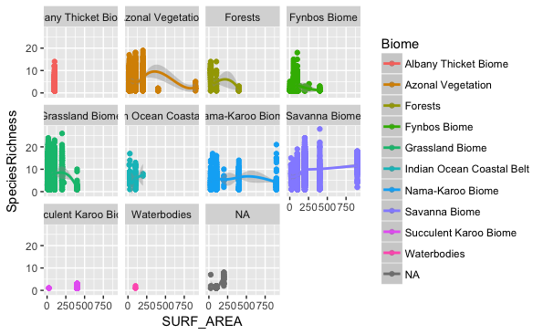

```r
d$SpeciesRichness <- rowSums(gdat)
ggplot(data = d, aes(x = SURF_AREA, y = SpeciesRichness, colour = Biome)) + geom_point() + facet_wrap(~Biome) + geom_smooth(method = "loess")
```

Probably looks better as boxplots:

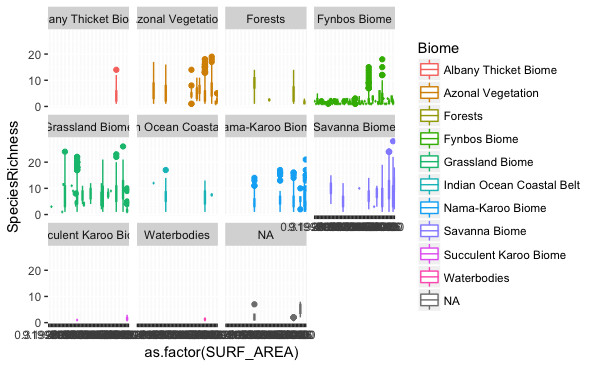

```r
ggplot(data = d, aes(x = as.factor(SURF_AREA), y = SpeciesRichness, colour = Biome)) + geom_boxplot() + facet_wrap(~Biome)
```

# Explore cutoffs for location confidence…

First a summary showing how many plots fall within each location confidence category:

```r
summary(as.factor(d$Loc_Conf))
```

```
   19    50    75   100   200   250   300   400   500   550   600   700  1000
 5416   412    79   755   204     5   492    42    25     1   847    11    15
 1150  1500  2000  2100  2200  2300  2400  2500  2560  2600  2700  2800  3000
 1072     2   262     1    13     1     1    24    79     3   126     1   150
 3100  3200  3300  3450  3500  3600  3800  4000  4100  4200  4300  4500  4700
    2     6     3    93   189     6     1   255    10    12    10   112     2
 4800  4900  5000  5200  5400  5500  5800  6000  6200  6300  6700  7000  7500
   18    19    37    36    12    26     6    28     5   121   148    27   200
 7800  8000  8400  9000 10000 12000 13000 17000 18000 30000 73000
    7     2     8    38    65   384  1066   116    87    97     1
```

How many plots with location confidence 5km or less?

```r
sum(d$Loc_Conf<5001)
```

```
[1] 10814
```

2km or less?

```r
sum(d$Loc_Conf<2001)
```

```
[1] 9640
```

Some plots in space to check coverage:

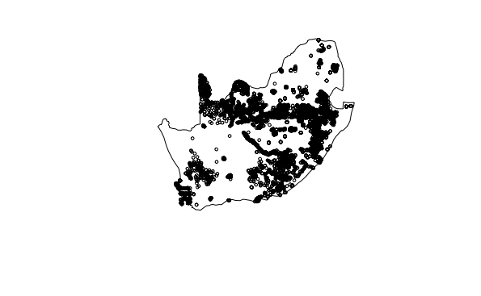

```r
#Make the plots a spatial object and project
spd <- d
coordinates(spd) <- ~ Long + Lat
proj4string(spd) <- "+proj=longlat +datum=WGS84 +no_defs +ellps=WGS84 +towgs84=0,0,0" #Assign a coordinate reference system (Geographic WGS84)
#Get a map of the outline of South Africa
map <- map("world", region = "south africa", fill = TRUE, plot=F)
IDs <- sapply(strsplit(map$names, ":"), function(x) x[1])
map <- map2SpatialPolygons(map, IDs=IDs, proj4string=CRS("+proj=longlat +datum=WGS84 +no_defs +ellps=WGS84 +towgs84=0,0,0"))
#Crop map to the extent of the points
map <- crop(map, extent(spd)+c(-1.5,1,-1,1))
#Plot the map
plot(map)
points(spd, cex=.5)
```